# **COVID-19 and Neurological Illness**

Meg Hutch, Trang Le, Chuan Hong, Xuan Wang, Zahra Shakeri

3/14/2022

This notebook describes the **87,869** hospitalized COVID-19 positive patients that were studied as part of the [Consortium for Clinical Characterization of COVID-19 by EHR](https://covidclinical.net/) Neurology group.

```r
library(tidyverse)
library(gridGraphics)
library(gridExtra)
library(ggpubr)
library(DT)
library(kableExtra)
library(cowplot)
library(RColorBrewer)
library(glue)
library(egg)
source("R/plot_theme.R")
```

# Import Data from each Healthcare system

```r
# read in files from results folder
# this folder contains all of the local healthcare system level analyses
rdas <- list.files(
  path = "results",
  pattern = ".rda",
  full.names = TRUE
)
for (rda in rdas) {
  load(rda)
}

rm(rdas, rda)

# create a list of participating healthcare systems from our study tracking spreadsheet
site_google_url <- "https://docs.google.com/spreadsheets/d/1epcYNd_0jCUMktOHf8mz5v651zy1JALD6PgzobrGWDY/edit?usp=sharing"

# load site parameters
site_params <- googlesheets4::read_sheet(site_google_url, sheet = 1)
site_avails <- googlesheets4::read_sheet(site_google_url, sheet = 2)

# filter the list of sites who ran the analysis
sorted_sites <- site_avails %>%
  filter(date_v3_received == 1) %>%
  pull(siteid) %>%
  paste("results", sep = "_")

# list sites without race
sites_wo_race <- site_params %>%
  filter(!include_race) %>%
  pull(siteid)

# combine all rda files with 'results' in name
results <- mget(ls(pattern = "results"))
```

# Demographics

## Pre-processing

**1. Format primary demographic characteristics**

```r
# create empty list to save demographics results
demo_table_list <- list()

# for each healthcare system, import the demographics table
for (i in sorted_sites) {
  tmp <- get(i)
  demo_table_list[[i]] <- tmp[[c(
    "first_hosp_results",
    "cpns_results",
    "demo_table"
  )]] %>%
    select(site, everything())
}

demo_table_wide <- bind_rows(demo_table_list) %>%
  mutate(
    # site level differences in variable names require tolower()
    site = toupper(site),
    variable = tolower(variable),
    # rename race.other to avoid recoding conflicts with age_group.other
    variable = if_else(variable == "race.other", "race.Other", variable),
    variable = if_else(variable == "age_group.other", "age_group.Unknown", variable),
    Demo_var = sub("\\..*", "", variable),
    Demo_var_i = sub(".*\\.", "", variable) %>%
      gsub("_", " ", .) %>%
      str_to_title() %>%
      recode(
        `00to02` = "0-2",
        `03to05` = "3-5",
        `06to11` = "6-11",
        `12to17` = "12-17",
        `18to25` = "18-25",
        `26to49` = "26-49",
        `50to69` = "50-69",
        `70to79` = "70-79",
        `80plus` = "80+",
        race.white = "White",
        race.american_indian = "American Indian",
        `Hawaiian Pacific Islander` = "Hawaiian/Pacific Islander",
        `Hispanic Latino` = "Hispanic/Latino",
        `False` = "Not Readmitted",
        `True` = "Readmitted"
      )
  )
```

**2. Format clinical characteristics (i.e: continuous variables such as median time to discharge)**

```r
# create empty list to save clinical-demographics results
clinical_table_list <- list()

# for each healthcare system, import the clinical-demographics table of continuous variable
for (i in sorted_sites) {
  tmp <- get(i)
  clinical_table_list[[i]] <- tmp[[c(
    "first_hosp_results",
    "cpns_results",
    "other_obfus_table"
  )]] %>%
    select(site, everything())
}

# create a dataframe with the continuous variables prefixed "Median"
clinical_table_wide <- bind_rows(clinical_table_list) %>%
  filter(grepl("Median", name))


# create a function to back-transform the pre-admission scores which were computed as log(z + 1)
# where z is the total number of pre CNS or PNS codes
transform_count <- function(z) {

  exp(z) - 1

}

# here we back-transform the median pre-admission scores and round them
clinical_table_wide_pre_adm <- clinical_table_wide %>%
  filter(name == "Median pre admission cns [Min, Max]" | name == "Median pre admission pns [Min, Max]") %>%
  separate(None, c("None_first", "None_min", "None_max"), sep=" ") %>%
  separate(Central, c("CNS_first", "CNS_min", "CNS_max"), sep=" ") %>%
  separate(Peripheral, c("PNS_first", "PNS_min", "PNS_max"), sep=" ") %>%
  mutate(across(None_first:CNS_max, ~ gsub("\\[|\\]", "", .x))) %>%
  mutate(across(None_first:CNS_max, ~ gsub(",", "", .x))) %>%
  mutate(across(None_first:CNS_max, ~ as.numeric(.) %>%
                  transform_count(.) %>%
                  round(., 1))) %>%
  mutate(None = paste0(None_first, " [", None_min, ",", None_max, "]"),
         Central = paste0(CNS_first, " [", CNS_min, ",", CNS_max, "]"),
         Peripheral = paste0(PNS_first, " [", PNS_min, ",", PNS_max, "]")) %>%
  select(site, name, None, Peripheral, Central)

# remove the old pre-admission scores
clinical_table_wide <- clinical_table_wide %>%
  filter(!name == "Median pre admission cns [Min, Max]",
         !name == "Median pre admission pns [Min, Max]",
         !name == "Mean pre admission cns (SD)",
         !name == "Mean pre admission pns (SD)")

# add revised pre-admission scores
clinical_table_wide <- rbind(clinical_table_wide, clinical_table_wide_pre_adm)
```

**3. Conduct additional pre-processing of clinical variables**

```r
# create a list of clinical variables to further pre-process
vars_to_process <- unique(clinical_table_wide$name)

# create an empty list to save pre-processed variables
processed_list <- list()

# for each variable, we will first remove the [min, max] from the median in order to convert the variable to numeric
# then we will calculate summary statistics (mean, median, min, max, sd)
for (i in vars_to_process) {
  mod_table <- clinical_table_wide %>%
    rename("var" = name) %>%
    filter(var == i) %>%
    mutate(
      site = toupper(site),
      None = sub("(\\(.*|\\[.*)", "", None),
      Peripheral = sub("(\\(.*|\\[.*)", "", Peripheral),
      Central = sub("(\\(.*|\\[.*)", "", Central)
    ) %>%
    mutate(across(None:Central, as.numeric)) %>%
    as_tibble() %>%
    select(-site, -var) %>%
    summarise_all(list(
      mean = mean,
      median = median,
      min = min,
      max = max,
      sd = sd
    ),
    na.rm = TRUE
    )

  processed_list[[i]] <- mod_table
}


# We will calculate the overal mean and standard deviation of the median clinical variables recorded by each healthcare system
clinical_table_compiled <- bind_rows(processed_list, .id = "Table 1") %>%
  filter(grepl("Median", `Table 1`)) %>%
  mutate(across(ends_with("mean"), ~ round(., 1))) %>%
  mutate(across(ends_with("sd"), ~ round(., 1))) %>%
  # get average of the medians
  mutate(
    None = glue("{None_mean} ({None_sd})"),
    Peripheral = glue("{Peripheral_mean} ({Peripheral_sd})"),
    Central = glue("{Central_mean} ({Central_sd})"),
    N = NA
  ) %>%
  select(`Table 1`, N, None, Peripheral, Central) %>%
  mutate(`Table 1` = gsub("\\[|\\]", " ", `Table 1`),
         `Table 1` = gsub("Min, Max", "(sd)", `Table 1`))
```

## Table One

```r
# sum up the total counts of each demographic variable across healthcare systems
tableOne_inter <- demo_table_wide %>%
  group_by(variable, Demo_var, Demo_var_i) %>%
  summarise(across(
    starts_with("n_var"),
    function(x) sum(x, na.rm = TRUE)
  ), .groups = "drop")

# order variables for appearence in table
ordered_vars <- c(
  "all", "sex", "age_group", "race",
  "readmitted", "severity", "survival"
)

# specify the order of Table 1
row_order <- c(
  "All Patients", "Female", "Male",
  "0-2", "3-5", "6-11", "12-17", "18-25",
  "26-49", "50-69", "70-79", "80+", "Unknown",
  "American Indian", "Asian", "Black",
  "Hawaiian/Pacific Islander",
  "Hispanic/Latino", "White", "Other",
  "Median Elixhauser score  (sd) ",
  "Median pre admission cns  (sd) ",
  "Median pre admission pns  (sd) ",
  "Non-Severe", "Severe",
  "Median time to severe  (sd) ",
  "Alive", "Deceased",
  "Median time to death  (sd) ",
  "Median time to first discharge  (sd) ",
  "Not Readmitted", "Readmitted",
  "Median time to first readmission  (sd) ",
  "Median number of readmissions  (sd) "
)

# filter and order table by specified variables
tableOne_raw <- tableOne_inter %>%
  filter(Demo_var == "sex") %>%
  summarise(across(where(is.numeric), sum)) %>%
  data.frame(
    variable = "all",
    Demo_var = "all",
    Demo_var_i = "All Patients",
    .
  ) %>%
  bind_rows(tableOne_inter) %>%
  mutate(
    N = rowSums(across(where(is.numeric))),
    Demo_var = factor(Demo_var, levels = ordered_vars)
  ) %>%
  group_by(Demo_var) %>%
  mutate(across(
    starts_with("n_var"),
    function(x) {
      paste0(x, " (", round(x / sum(x, na.rm = TRUE) * 100, 1), "%", ")")
    }
  )) %>%
  ungroup() %>%
  arrange(Demo_var) %>%
  select(Demo_var_i, N, starts_with("n_var")) %>%
  `colnames<-`(gsub(
    x = names(.),
    pattern = "n_var_",
    replacement = ""
  )) %>%
  rename("Table 1" = Demo_var_i) %>%
  bind_rows(clinical_table_compiled) %>%
  slice(match(row_order, `Table 1`))

# define function to pull overall patient counts
get_table_n <- function(var) {
  tableOne_raw %>%
    filter(`Table 1` == var) %>%
    pull(N)
}

# Add total patient counts to table 1
tableOne_compiled <- tableOne_raw %>%
  mutate(
    N = case_when(
      grepl("Median time to first discharge", `Table 1`) ~ get_table_n("All Patients"),
      grepl("Median time to last discharge", `Table 1`) ~ get_table_n("All Patients"),
      grepl("Median time to severe", `Table 1`) ~ get_table_n("Severe"),
      grepl("death", `Table 1`) ~ get_table_n("Deceased"),
      grepl("readmission", `Table 1`) ~ get_table_n("Readmitted"),
      grepl("Median Elixhauser score", `Table 1`) ~ get_table_n("All Patients"),
      TRUE ~ N
    )
  ) %>%
  mutate(N = if_else(`Table 1` == "Median pre admission cns  (sd) " | `Table 1` == "Median pre admission pns  (sd) ",
              get_table_n("All Patients"), N),
         # N for the time to first discharge is hardcoded as it was calculated from the survival curve estimated n.risk. Some patients were still in the hospital at the time of data collection
         N = if_else(`Table 1` == "Median time to first discharge  (sd) ", 72621, N))  %>%
  select(`Table 1`, N, None, Central, Peripheral)


# plot Table 1
kbl(tableOne_compiled %>%
      rename("No Neurological Condition (NNC)" = None)) %>%
  add_header_above(c(
    " ",
    "Total Patients" = 1,
    "Neurological Disease" = 3
  )) %>%
  kable_paper("striped", full_width = F) %>%
  pack_rows("Sex", 2, 3) %>%
  pack_rows("Age", 4, 13) %>%
  pack_rows("Race & Ethnicity", 14, 20) %>%
  pack_rows("Past Medical History", 21, 23) %>%
  pack_rows("Severity", 24, 26) %>%
  pack_rows("Survival", 27, 29) %>%
  pack_rows("Discharge & Readmission", 30, 34)
```

| Table 1 | Total Patients N | Neurological Disease No Neurological Condition (NNC) | Neurological Disease Central | Neurological Disease Peripheral |
| --- | --- | --- | --- | --- |
| All Patients | 87869 | 71890 (100%) | 13518 (100%) | 2461 (100%) |
| **Sex** |  |  |  |  |
| Female | 28592 | 24307 (33.8%) | 3504 (25.9%) | 781 (31.7%) |
| Male | 59277 | 47583 (66.2%) | 10014 (74.1%) | 1680 (68.3%) |
| **Age** |  |  |  |  |
| 0-2 | 567 | 533 (0.7%) | 34 (0.3%) | 0 (0%) |
| 3-5 | 148 | 143 (0.2%) | 5 (0%) | 0 (0%) |
| 6-11 | 250 | 229 (0.3%) | 19 (0.1%) | 2 (0.1%) |
| 12-17 | 493 | 441 (0.6%) | 43 (0.3%) | 9 (0.4%) |
| 18-25 | 1774 | 1628 (2.3%) | 120 (0.9%) | 26 (1.1%) |
| 26-49 | 13907 | 12521 (17.4%) | 950 (7.1%) | 436 (18.1%) |
| 50-69 | 30677 | 25942 (36.1%) | 3694 (27.5%) | 1041 (43.3%) |
| 70-79 | 21778 | 17015 (23.7%) | 4167 (31%) | 596 (24.8%) |
| 80+ | 18098 | 13384 (18.6%) | 4419 (32.9%) | 295 (12.3%) |
| Unknown | 25 | 25 (0%) | 0 (0%) | 0 (0%) |
| **Race & Ethnicity** |  |  |  |  |
| American Indian | 318 | 254 (0.4%) | 64 (0.5%) | 0 (0%) |
| Asian | 1476 | 1273 (1.8%) | 184 (1.4%) | 19 (0.8%) |
| Black | 14486 | 11269 (15.7%) | 2801 (20.8%) | 416 (17.5%) |
| Hawaiian/Pacific Islander | 282 | 239 (0.3%) | 42 (0.3%) | 1 (0%) |
| Hispanic/Latino | 910 | 832 (1.2%) | 66 (0.5%) | 12 (0.5%) |
| White | 33669 | 26359 (36.7%) | 6397 (47.5%) | 913 (38.4%) |
| Other | 36576 | 31657 (44%) | 3901 (29%) | 1018 (42.8%) |
| **Past Medical History** |  |  |  |  |
| Median Elixhauser score (sd) | 87869 | 0.2 (0.9) | 1.8 (3.1) | 0.5 (1.7) |
| Median pre admission cns (sd) | 87869 | 0 (0) | 0.1 (0.4) | 0 (0) |
| Median pre admission pns (sd) | 87869 | 0 (0) | 0 (0) | 0 (0.1) |
| **Severity** |  |  |  |  |
| Non-Severe | 55045 | 47333 (65.8%) | 6338 (46.9%) | 1374 (55.6%) |
| Severe | 32835 | 24557 (34.2%) | 7180 (53.1%) | 1098 (44.4%) |
| Median time to severe (sd) | 32835 | 1 (1.7) | 0.4 (0.7) | 0.6 (0.9) |
| **Survival** |  |  |  |  |
| Alive | 73043 | 61302 (85.3%) | 9433 (69.8%) | 2308 (93.5%) |
| Deceased | 14833 | 10587 (14.7%) | 4085 (30.2%) | 161 (6.5%) |
| Median time to death (sd) | 14833 | 21.3 (32.6) | 20.5 (31.1) | 15.5 (12.1) |
| **Discharge & Readmission** |  |  |  |  |
| Median time to first discharge (sd) | 72621 | 6.2 (3.5) | 12.1 (6.2) | 12.5 (16.6) |
| Not Readmitted | 76908 | 63288 (88%) | 11499 (85.1%) | 2121 (86.3%) |
| Readmitted | 10957 | 8602 (12%) | 2018 (14.9%) | 337 (13.7%) |
| Median time to first readmission (sd) | 10957 | 22.8 (14.1) | 24.5 (20.5) | 32.5 (23.4) |
| Median number of readmissions (sd) | 10957 | 0 (0) | 0 (0.2) | 0 (0.2) |

```r
write.csv(tableOne_compiled, "tables/Table1.csv", row.names = FALSE)
```

### Evaluate characteristics among neuro status groups

**1. Conduct chi-squared tests for categorical demographic variables**

```r
# total patients
N = tableOne_compiled %>% select(N) %>% head(1) %>% as.numeric()

# sum of all neuro condition groups
cns_n = as.numeric(gsub( " .*$", "", tableOne_compiled[1,"Central"]))
pns_n = as.numeric(gsub( " .*$", "", tableOne_compiled[1,"Peripheral"]))
none_n = as.numeric(gsub( " .*$", "", tableOne_compiled[1,"None"]))

# create list of demographic/clinical variables
vars = tableOne_inter$variable

# for binary variables, we should group by category
# Thus, only run the analysis for sex.male rather than both sex.female AND sex.male which would be redundant
exclude <- c("readmitted.false", "sex.female", "survival.deceased", "severity.non-severe")
vars <- vars[!vars %in% exclude]

# create a function to calculate chi.square tests
calc_chisq <- function(var) {

  # define matrix for each variable
  mat <- tableOne_inter %>%
  filter(variable == paste(var)) %>%
  select(starts_with("n_var")) %>%
  mutate(none_dif = none_n - n_var_None,
         pns_dif = pns_n - n_var_Peripheral,
         cns_dif = cns_n - n_var_Central) %>%
  as.integer() %>%
  matrix(nrow = 2, ncol = 3, byrow = TRUE)

  result <- chisq.test(unlist(mat))

}

# create empty list for chi.square test results
chi_result_list = list()

# for each variable, we will run the chi.square test
for(i in vars) {

  test = calc_chisq(i)
  X2 <- round(test$statistic, 4)
  p_value <- test$p.value
  df <- test$parameter
  Variable = paste(i)

  chi_results <- cbind(Variable, X2, p_value, df) %>%
    data.frame()

  rownames(chi_results) <- NULL

  chi_result_list[[i]] <- chi_results
}
# save list of chi.square test results
chisq_results <- bind_rows(chi_result_list)
```

**2. Conduct anova (Kruskal-Wallis) tests for continuous clinical variables**

```r
# create empty list to save processed variables
processed_list_figs <- list()

# for each variable, we will remove the [min, max] as before
for (i in vars_to_process) {
  mod_table <- clinical_table_wide %>%
    rename("var" = name) %>%
    filter(var == i) %>%
    mutate(
      site = toupper(site),
      None = sub("(\\(.*|\\[.*)", "", None),
      Peripheral = sub("(\\(.*|\\[.*)", "", Peripheral),
      Central = sub("(\\(.*|\\[.*)", "", Central)
    ) %>%
    mutate(across(None:Central, as.numeric))

  processed_list_figs[[i]] <- mod_table
}

clinical_table_anova <- bind_rows(processed_list_figs)

# format the continuous variables
cont_vars = clinical_table_anova %>%
  mutate(
    # create a variable without mean/median prefix
    grouped_var = gsub("Mean |Median | \\[Min, Max\\]| \\(SD\\)", "", var)
  ) %>%
  pivot_longer(
    cols = None:Central,
    names_to = "type"
  ) %>%
  mutate(type = factor(type, levels = c("None", "Central", "Peripheral"))) %>%
  # select variables to analyze
  filter(grouped_var %in% c("Elixhauser score",
                            "pre admission cns",
                            "pre admission pns",
                            "time to death",
                            "time to first discharge",
                            "time to severe",
                            "number of readmissions",
                            "time to first readmission")) %>%
  distinct()

# create function to conduct anova
cont_var_results <- function(variable) {

  df <- cont_vars %>%
  filter(grouped_var == paste(variable))

  # kruskal.test calculates the kruskal-Wallis H-statistic
  # does not assume normality between groups
  # also called the one-way ANOVA on ranks
  test = kruskal.test(df$value ~ df$type)

}

# create empty list for Kruskal-Wallis results
cont_vars_list = list()

# create list of unique variables
outcome_cont_vars = unique(cont_vars$grouped_var)

for(i in outcome_cont_vars) {

  test = cont_var_results(i)
  X2 <- round(test$statistic, 4)
  p_value <- test$p.value
  df <- test$parameter
  Variable = paste(i)

  kw <- cbind(Variable, X2, p_value, df) %>%
    data.frame()

  rownames(kw) <- NULL

  cont_vars_list[[i]] <- kw


}

anova_results <- bind_rows(cont_vars_list)
```

**3. Combine chi-square and Kruskal-Wallis results**

We will evaluate significance when controlling for False Discovery Rate (FDR)

```r
demo_stats <- rbind(chisq_results %>% select(Variable, p_value),
                    anova_results %>% select(Variable, p_value))

# adjust p-values with FDR
demo_stats$adj_p_value <- p.adjust(demo_stats$p_value, method = "fdr")

demo_stats <- demo_stats %>%
  mutate(p_value = as.numeric(p_value),
         pvalue = if_else(p_value < 0.001, "< 0.001", paste(round(p_value, 3))),
         adj.p_value = if_else(adj_p_value < 0.001, "< 0.001", paste(round(adj_p_value, 3))))

# tidy up the demographics stat table
demo_stats_tidy <- demo_stats %>%
  rename(`Unadjusted P-value` = p_value,
         `FDR Adjusted P-value` = adj_p_value) %>%
  select(Variable, `Unadjusted P-value`, `FDR Adjusted P-value`)

datatable(demo_stats_tidy)
```

|  | Variable | Unadjusted P-value | FDR Adjusted P-value |
| --- | --- | --- | --- |
| 1 | age_group.00to02 | 1.51360048918067e-13 | 3.37649339894149e-13 |
| 2 | age_group.03to05 | 1.65783881410571e-05 | 3.0048328505666e-05 |
| 3 | age_group.06to11 | 0.000275699455184175 | 0.000420804431596899 |
| 4 | age_group.12to17 | 5.76677464450575e-05 | 9.83743909945098e-05 |
| 5 | age_group.18to25 | 5.58156238697726e-27 | 1.47150281111219e-26 |
| 6 | age_group.26to49 | 2.19574608843721e-202 | 1.27353273129358e-201 |
| 7 | age_group.50to69 | 2.35555946994438e-97 | 9.75874637548386e-97 |
| 8 | age_group.70to79 | 1.01358493862377e-68 | 3.26599591334326e-68 |
| 9 | age_group.80plus | 0 | 0 |
| 10 | age_group.Unknown | 0.0620901821551353 | 0.0782876209782141 |

[output cut: 19 more lines]

```r
write.csv(demo_stats, "tables/Table1_pvals.csv", row.names = FALSE)
```

## Diagnoses

Evaluate CNS and PNS neurological diagnoses in our patient cohort

```r
# import list of ICD-9/ICD-10 codes
neuro_icds_10 <-
  readxl::read_excel("public-data/2020-02-22_neuro-icd10_CNSvPNS.xlsx") %>%
  rename(
    "icd" = `ICD-10`,
    "pns_cns" = `Nervous system Involvement (1=central, 2=peripheral)`
  ) %>%
  mutate(pns_cns = as.factor(pns_cns) %>% fct_recode(
    Central = "1",
    Peripheral = "2"
  )) %>%
  select(icd, `Neurological Disease Category`, pns_cns, `ICD-10 Description`) %>%
  rename("description" = `ICD-10 Description`) %>%
  mutate(concept_type = "icd-10")

neuro_icds_9 <- read.csv("public-data/icd9_tab_CNSvPNS.csv") %>%
  rename(
    "Neurological Disease Category" = "Neurological.Disease.Category",
    "pns_cns" = `Nervous.system.Involvement..1.central..2.peripheral.`,
    "icd_description" = `icd9_desc`
  ) %>%
  mutate(
    pns_cns = as.factor(pns_cns) %>% fct_recode(
      Central = "1",
      Peripheral = "2"
    ),
    concept_type = "DIAG-ICD9"
  ) %>%
  select(icd, `Neurological Disease Category`, pns_cns, icd_description) %>%
  rename("description" = icd_description) %>%
  mutate(concept_type = "icd-9")

# bind list of ICD-9/ICD-10 codes
icds <- rbind(neuro_icds_10, neuro_icds_9)

# create empty list to save processed diagnostic data
diag_table_list <- list()

# for each healthcare system, we will calculate the total number of patients with each ICD code
for (i in sorted_sites) {
  tmp <- get(i)
  tmp_diag <- tmp[[c(
    "first_hosp_results",
    "icd_tables",
    "demo_table"
  )]]
  tmp_diag$site <- tmp[["site"]]
  diag_table_list[[i]] <- tmp_diag %>%
    filter(variable == "sex.female" | variable == "sex.male") %>%
    select(site, contains("n_var"))
}

diag_table_wide <- bind_rows(diag_table_list)

# we will count the total number and percent across healthcare systems
diag_counts <- colSums(Filter(is.numeric, diag_table_wide), na.rm = TRUE) %>%
  data.frame() %>%
  mutate(perc = round(./N * 100, 1))

# format diagnostic table
diag_counts <- tibble::rownames_to_column(diag_counts, "icd") %>%
  mutate(icd = gsub("n_var_", "", icd)) %>%
  rename(`Number of Patients` = ".") %>%
  full_join(., icds, by = "icd") %>%
  dplyr::arrange(desc(`Number of Patients`)) %>%
  mutate(`Number of Patients (% of Cohort)` = paste(`Number of Patients`, "(", perc, ")", sep = " ")) %>%
  select(pns_cns, `Neurological Disease Category`, concept_type,
         icd, description, `Number of Patients (% of Cohort)`) %>%
    rename(Code = "icd",
         `Nervous System` = "pns_cns",
         Description = "description",
         `ICD Version` = "concept_type") %>%
  mutate(`Number of Patients (% of Cohort)` = if_else(`Number of Patients (% of Cohort)` == "NA ( NA )", "0 ( 0 )", `Number of Patients (% of Cohort)`),
         Code = if_else(Code == "NN", "No Neurological Disease (NNC)", Code))

datatable(diag_counts, caption = "Number (%) of Patients with each Neurological Diagnosis")
```

|  | Nervous System | Neurological Disease Category | ICD Version | Code | Description | Number of Patients (% of Cohort) |
| --- | --- | --- | --- | --- | --- | --- |
| 1 |  |  |  | No Neurological Disease (NNC) |  | 71918 ( 81.8 ) |
| 2 | Central | Consciousness | icd-10 | R41 | Other symptoms and signs involving cognitive functions and awareness | 6894 ( 7.8 ) |
| 3 | Central | Other | icd-10 | G93 | Other disorders of the brain | 4985 ( 5.7 ) |
| 4 | Central | Seizure | icd-10 | G40 | Epilepsy and recurrent seizures | 2128 ( 2.4 ) |
| 5 | Peripheral | Dizziness | icd-10 | R42 | Dizziness and giddiness | 1039 ( 1.2 ) |
| 6 | Peripheral | Neuropathy | icd-10 | R43 | Disturbances of smell and taste | 769 ( 0.9 ) |
| 7 | Central | Vision | icd-10 | H54 | Blindness and low vision | 728 ( 0.8 ) |
| 8 | Central | Vascular | icd-10 | I67 | Other cerebrovascular diseases | 726 ( 0.8 ) |
| 9 | Central | Psychiatric | icd-10 | F29 | Unspecified psychosis not due to a substance or known physiological condition | 366 ( 0.4 ) |
| 10 | Central | Vascular | icd-10 | G45 | Transient cerebral ischemic attacks and related syndromes | 364 ( 0.4 ) |

[output cut: 41 more lines]

```r
write.csv(diag_counts, "tables/Supp.Table2_diagnoses.csv", row.names = FALSE)
```

## Evaluate Diagnoses by Age

```r
for (i in sorted_sites) {
  tmp <- get(i)
  tmp_diag <- tmp[[c(
    "first_hosp_results",
    "icd_tables",
    "demo_table"
  )]]
  tmp_diag$site <- tmp[["site"]]
  diag_table_list[[i]] <- tmp_diag %>%
    select(variable, starts_with("n_var")) %>%
    pivot_longer(cols = starts_with("n_var"), names_to = "code", values_to = "freq") %>%
    ungroup()
}

diag_table_wide_all <- bind_rows(diag_table_list) %>%
    group_by(variable, code) %>%
  # total number of patients who had each code for each variable across sites
    mutate(total_n_var  = sum(freq, na.rm = TRUE)) %>%
  distinct(variable, code, total_n_var) %>%
  mutate(code = gsub("n_var_", "", code),
         variable = gsub("Severity.", "", variable),
         variable = gsub("Survival.", "", variable),
         variable = gsub("readmitted", "", variable),
         variable = gsub("age_group", "", variable),
         variable = if_else(variable == ".TRUE", "Readmitted", variable)) %>%
  left_join(., icds %>% rename(code = "icd"), by = "code")


## Plot diagnosis by age

# create function to grab total count by variable
n_0_2 <- get_table_n(var = "0-2")
n_3_5 = get_table_n(var = "3-5")
n_6_11 = get_table_n(var = "6-11")
n_12_17 = get_table_n(var = "12-17")
n_18_25 = get_table_n(var = "18-25")
n_26_49 = get_table_n(var = "26-49")
n_50_69 = get_table_n(var = "50-69")
n_70_79 = get_table_n(var = "70-79")
n_80 = get_table_n(var = "80+")

# refactor neuro status
diag_table_wide_all$pns_cns <- factor(diag_table_wide_all$pns_cns,
                                      levels=c("Central", "Peripheral"),
                                      labels=c("CNS", "PNS"))

# create copy of dataframe for age analysis
diag_table_wide_all_age <- diag_table_wide_all

diag_table_wide_all_age$variable <- factor(diag_table_wide_all_age$variable,
                                   levels=c(".00to02", ".03to05", ".06to11", ".12to17",
                                            ".18to25", ".26to49", ".50to69", ".70to79", ".80plus"),
                                   labels=c("0-2 Years", "3-5 Years", "6-11 Years", "12-17 Years",
                                            "18-25 Years", "26-49 Years", "50-69 Years", "70-79 Years", "80+ Years"))

group.colors <- c(NNC = "#621561", PNS = "#d90429", CNS ="#d6b9b4")
```

**Pediatrics**

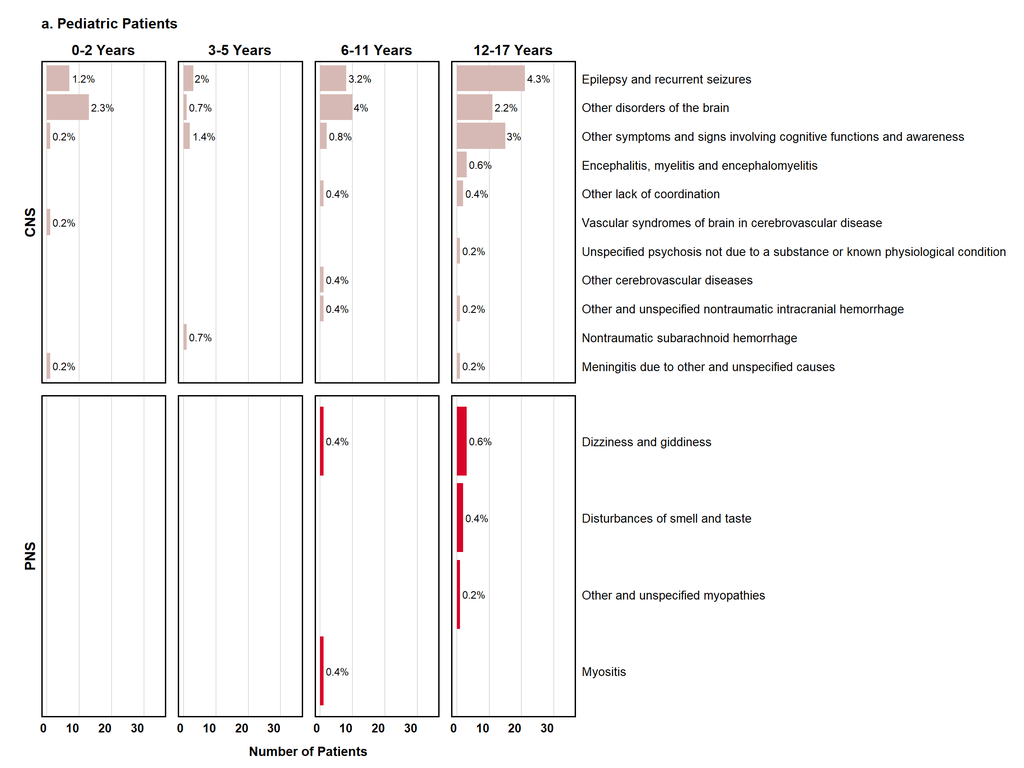

```r
pediatric_plot <- ggplot(diag_table_wide_all_age %>%
         filter(variable %in% c("0-2 Years", "3-5 Years", "6-11 Years", "12-17 Years"),
                !code == "NN",
                !total_n_var == 0) %>%
         # total_n would be calculating total codes across each age group which is not true refrlection of patient counts b/c patients can have more than one code
         #mutate(total_n = sum(total_n_var)) %>%
         ungroup() %>%
         mutate(perc = case_when(variable == "0-2 Years" ~ round(total_n_var/n_0_2*100,1),
                                 variable == "3-5 Years" ~ round(total_n_var/n_3_5*100,1),
                                 variable == "6-11 Years" ~ round(total_n_var/n_6_11*100,1),
                                 variable == "12-17 Years" ~ round(total_n_var/n_12_17*100,1)),

                #perc = round(total_n_var/total_n*100,1),
                perc = paste0(perc, "%")),
       aes(x = total_n_var, y = reorder(description, total_n_var), fill = pns_cns)) +
  geom_bar(stat = "identity") +
 geom_text(
    aes(x = total_n_var, y = description, label = perc),
    hjust = -0.1, size = 3,
    position = position_dodge(width = 1),
    inherit.aes = TRUE
  ) +
  facet_grid(pns_cns ~ variable, switch="y", scale = "free_y") +   # Put the y facet strips on the left
  scale_y_discrete("", position="right") +   # Put the y-axis labels on the right
  scale_fill_manual(values = group.colors) +
  ylab("") +
  xlab("Number of Patients") +
  xlim(0, 35) +
  ggtitle("a. Pediatric Patients") +
  theme(plot.title = element_text(size = 12, face = "bold", hjust = 0))

pediatric_plot
```

```r
ggsave("figures/Fig3A_diagnoses_by_age_pediatrics.jpg", width = 12, height = 7, dpi = 300)
```

**Adults**

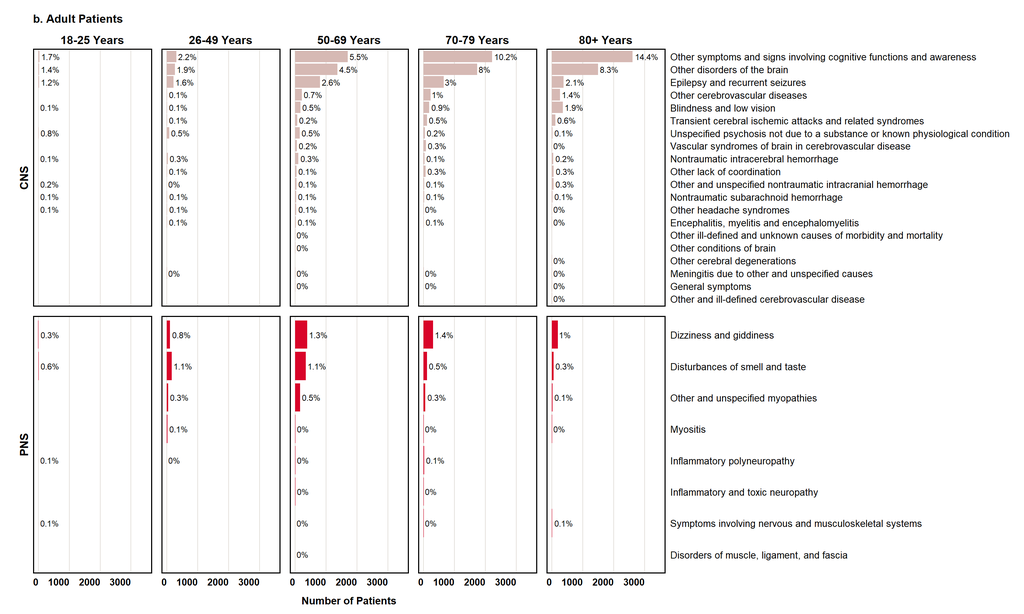

```r
adult_plot <- ggplot(diag_table_wide_all_age %>%
         filter(variable %in% c("18-25 Years", "26-49 Years", "50-69 Years", "70-79 Years", "80+ Years"),
                !code == "NN",
                !total_n_var == 0) %>%
         # total_n would be calculating total codes across each age group which is not true refrlection of patient counts b/c patients can have more than one code
         #mutate(total_n = sum(total_n_var)) %>%
         ungroup() %>%
         mutate(perc = case_when(variable == "18-25 Years" ~ round(total_n_var/n_18_25*100,1),
                                 variable == "26-49 Years" ~ round(total_n_var/n_26_49*100,1),
                                 variable == "50-69 Years" ~ round(total_n_var/n_50_69*100,1),
                                 variable == "70-79 Years" ~ round(total_n_var/n_70_79*100,1),
                                 variable == "80+ Years" ~ round(total_n_var/n_80*100,1)),

                #perc = round(total_n_var/total_n*100,1),
                perc = paste0(perc, "%")),
       aes(x = total_n_var, y = reorder(description, total_n_var), fill = pns_cns)) +
  geom_bar(stat = "identity") +
 geom_text(
    aes(x = total_n_var, y = description, label = perc),
    hjust = -0.1, size = 3,
    position = position_dodge(width = 1),
    inherit.aes = TRUE
  ) +
  facet_grid(pns_cns ~ variable, switch="y", scale = "free_y") +   # Put the y facet strips on the left
  scale_y_discrete("", position="right", labels = function(x) str_wrap(x, width = 150)) +   # Put the y-axis labels on the right
  scale_fill_manual(values = group.colors) +
  ylab("") +
  xlab("Number of Patients") +
  xlim(0, 3500) +
  ggtitle("b. Adult Patients")  +
  theme(plot.title = element_text(size = 12, face = "bold", hjust = 0))

adult_plot
```

```r
ggsave("figures/Fig3B_diagnoses_by_age_adult.jpg", width = 14, height = 12, dpi = 300)
```

**Diagnoses by Age**

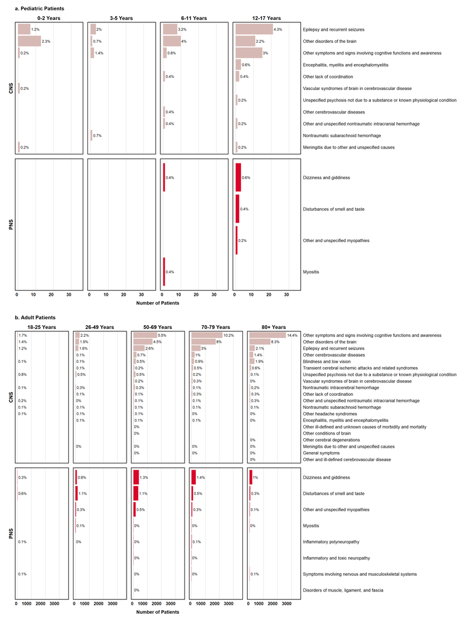

```r
grid.arrange(pediatric_plot, adult_plot, ncol=1)
```

```r
ggsave("figures/Figure3.Diagnoses_by_age.pdf", grid.arrange(pediatric_plot, adult_plot, ncol=1), width = 18, height = 15, dpi = 300)
```

## Evaluate Diagnoses by Outcome

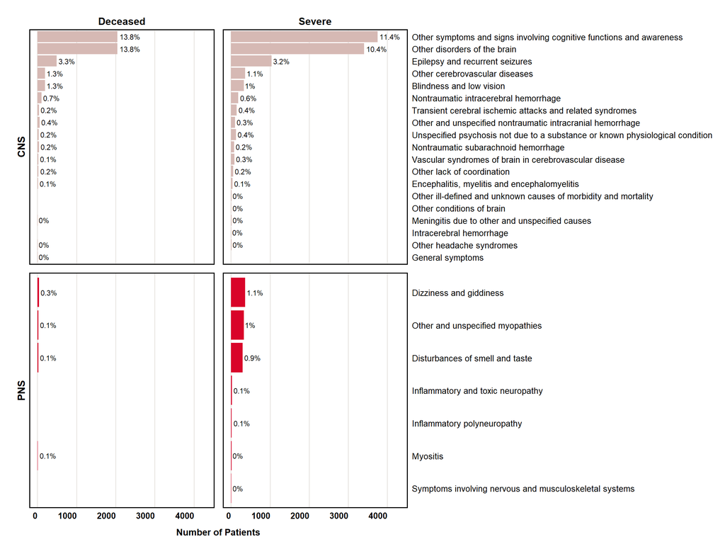

```r
## determine total number of patients who died or severe
n_death = get_table_n(var = "Deceased")

n_severe = get_table_n(var = "Severe")

ggplot(diag_table_wide_all %>%
         filter(variable %in% c("Severe", "Deceased"),
                !code == "NN",
                !total_n_var == 0) %>%
         group_by(variable) %>%
         # total_n would be calculating total codes across each outcome group which is not true reflection of patient counts b/c patients can have more than one code
         #mutate(total_n = sum(total_n_var)) %>%
         ungroup() %>%
         mutate(perc = if_else(variable == "Severe", round(total_n_var/n_severe*100,1),
                               round(total_n_var/n_death*100,1)),
                perc = paste0(perc,"%")),
       aes(x = total_n_var, y = reorder(description, total_n_var), fill = pns_cns)) +
  geom_bar(stat = "identity") +
 geom_text(
    aes(x = total_n_var, y = description, label = perc),
    hjust = -0.1, size = 3,
    position = position_dodge(width = 1),
    inherit.aes = TRUE
  ) +
  facet_grid(pns_cns ~ variable, switch="y", scale = "free_y") +   # Put the y facet strips on the left
  scale_y_discrete("", position="right") +   # Put the y-axis labels on the right
  scale_fill_manual(values = group.colors) +
  ylab("") +
  xlab("Number of Patients") +
  xlim(0, 4300)
```

```r
ggsave("figures/SuppFig1_diagnoses_by_outcomes.png", width = 14, height = 9, dpi = 300)
```

## Evaluate patients with “Both” CNS and PNS diseases

These patients were excluded from the primary analysis due to potential confounding.

```r
# create empty list to store the counts of "both" patients
both_counts_list <- list()

# for each healthcare system, retrieve the number of excluded "both" patients recorded
for (i in sorted_sites) {
  n_both <- results[[paste(i)]][["first_hosp_results"]][["both"]]

  both_counts_list[[i]] <- n_both
}

both_counts <- bind_rows(both_counts_list) %>% t() %>% data.frame() %>% sum()

print(paste(both_counts, "(", round(both_counts/(N+both_counts)*100,2), "%)"))
```

```
## [1] "809 ( 0.91 %)"
```

## Comordities

Next, we will evaluate patient’s pre-existing comorbidities.

First, we will create a list of comorbidities, which will help us deal with data cleaning issues.

Comorbidity list obtained from icd package icd/data/mappingNames, which was used to calculate the Elixhauser comorbidity score in the analysis

```r
# HTN marked together as combined, but DM not.
names_elix_htn <- list(
  "01" = "Congestive heart failure",
  "02" = "Cardiac arrhythmias",
  "03" = "Valvular disease",
  "04" = "Pulmonary circulation disorders",
  "05" = "Peripheral vascular disorders",
  "06a" = "Hypertension, uncomplicated",
  "06b" = "Hypertension, complicated",
  "07" = "Paralysis",
  "08" = "Other neurological disorders",
  "09" = "Chronic pulmonary disease",
  "10" = "Diabetes, uncomplicated",
  "11" = "Diabetes, complicated",
  "12" = "Hypothyroidism",
  "13" = "Renal failure",
  "14" = "Liver disease",
  "15" = "Peptic ulcer disease excluding bleeding",
  "16" = "HIV/AIDS",
  "17" = "Lymphoma",
  "18" = "Metastatic cancer",
  "19" = "Solid tumor without metastasis",
  "20" = "Rheumatoid arthritis/collagen vascular diseases",
  "21" = "Coagulopathy",
  "22" = "Obesity",
  "23" = "Weight loss",
  "24" = "Fluid and electrolye disorders",
  "25" = "Blood loss anemia",
  "26" = "Deficiency anemias",
  "27" = "Alcohol abuse",
  "28" = "Drug abuse",
  "29" = "Psychoses",
  "30" = "Depression"
)

# Elixhauser with HTN combined:
comorb_list <- names_elix_htn
comorb_list["06b"] <- NULL
comorb_list["06a"] <- "Hypertension, combined"
names(comorb_list)[6] <- "06"

Comorbidity <- unlist(comorb_list)
Comorbidity <- as.data.frame(Comorbidity)

Comorbidity <- tibble::rownames_to_column(Comorbidity, "Abbreviation")

# modify BCH - their comorbidity abbreviations were not included for some reason
#View(BCH_results[["first_hosp_results"]][["cpns_results"]][["elix_obfus_table1"]][["Comorbidity"]])

# create temp dataframe for BCH and map abbreviations to the abbreviation number
df <- BCH_results[["first_hosp_results"]][["cpns_results"]][["elix_obfus_table1"]] %>%
  arrange(Abbreviation) %>%
  select(-Comorbidity) %>%
  left_join(., Comorbidity, by = "Abbreviation")

# replace BCH comorbidity results to our modified table
BCH_results[["first_hosp_results"]][["cpns_results"]][["elix_obfus_table1"]] <- df
```

Next, we will continue pre-processing the comorbidities data for all healthcare systems.

```r
# create empty list to store comorbidities
comorb_table_list <- list()

# because Elixhauser comorbidity index has two diabetes categories which capture the same diagnoses once we employ our truncation method, we will remove one of the diabetes categories
for (i in sorted_sites) {
  tmp <- get(i)
  tmp_comorb <- tmp[[c(
    "first_hosp_results",
    "cpns_results",
    "elix_obfus_table1"
  )]]
  tmp_comorb$site <- tmp[["site"]]
  comorb_table_list[[i]] <- tmp_comorb %>%
    filter(!Comorbidity == "Diabetes, uncomplicated") %>%
    mutate(Comorbidity = if_else(Comorbidity == "Diabetes, complicated", "Diabetes", Comorbidity)) %>%
    select(site, Comorbidity,  n_Total, n_None, n_Central, n_Peripheral)
}

# calculate total number of patients with each comorbidity across neurological status
comorb_table_wide <- bind_rows(comorb_table_list) %>%
  data.frame() %>%
  group_by(Comorbidity) %>%
  mutate(Comorb_Total = sum(n_Total, na.rm = TRUE),
         Comorb_Perc = round(Comorb_Total/as.numeric(tableOne_compiled[1,"N"])*100, 1)) %>%
  arrange(desc(Comorb_Perc)) %>%
  mutate(None_Total = sum(n_None, na.rm = TRUE),
         None_Perc = round(None_Total/as.numeric(gsub( " .*$", "", tableOne_compiled[1,"None"])) * 100, 1),
         CNS_Total = sum(n_Central, na.rm = TRUE),
         CNS_Perc = round(CNS_Total/as.numeric(gsub( " .*$", "", tableOne_compiled[1,"Central"])) * 100, 1),
         PNS_Total = sum(n_Peripheral, na.rm = TRUE),
         PNS_Perc = round(PNS_Total/as.numeric(gsub( " .*$", "", tableOne_compiled[1,"Peripheral"])) * 100, 1)) %>%
  ungroup() %>%
  distinct(Comorbidity, Comorb_Total, None_Total, CNS_Total, PNS_Total,
           Comorb_Perc, None_Perc, CNS_Perc, PNS_Perc)


comorb_table_plot <- comorb_table_wide %>%
  mutate(Comorb_Total = paste(Comorb_Total, "(", Comorb_Perc, ")"),
         None_Total = paste(None_Total, "(", None_Perc, ")"),
         CNS_Total = paste(CNS_Total, "(", CNS_Perc, ")"),
         PNS_Total = paste(PNS_Total, "(", PNS_Perc, ")")) %>%
  distinct(Comorbidity, Comorb_Total, None_Total, CNS_Total, PNS_Total) %>%
  rename("Total" = Comorb_Total,
         "NNC" = None_Total,
         "CNS" = CNS_Total,
         "PNS" = PNS_Total)

datatable(comorb_table_plot, caption = "Number of Patients with each Pre-existing Comorbidity by Neurological Status")
```

|  | Comorbidity | Total | NNC | CNS | PNS |
| --- | --- | --- | --- | --- | --- |
| 1 | Hypertension, combined | 31593 ( 36 ) | 24115 ( 33.5 ) | 6584 ( 48.7 ) | 894 ( 36.3 ) |
| 2 | Alcohol abuse | 28369 ( 32.3 ) | 21704 ( 30.2 ) | 5849 ( 43.3 ) | 816 ( 33.2 ) |
| 3 | Drug abuse | 25477 ( 29 ) | 19469 ( 27.1 ) | 5271 ( 39 ) | 737 ( 29.9 ) |
| 4 | Diabetes | 19804 ( 22.5 ) | 15159 ( 21.1 ) | 4057 ( 30 ) | 588 ( 23.9 ) |
| 5 | Cardiac arrhythmias | 16821 ( 19.1 ) | 12600 ( 17.5 ) | 3737 ( 27.6 ) | 484 ( 19.7 ) |
| 6 | Depression | 16645 ( 18.9 ) | 12491 ( 17.4 ) | 3650 ( 27 ) | 504 ( 20.5 ) |
| 7 | Congestive heart failure | 15777 ( 18 ) | 11904 ( 16.6 ) | 3467 ( 25.6 ) | 406 ( 16.5 ) |
| 8 | Renal failure | 13519 ( 15.4 ) | 10147 ( 14.1 ) | 3009 ( 22.3 ) | 363 ( 14.8 ) |
| 9 | Chronic pulmonary disease | 12197 ( 13.9 ) | 9555 ( 13.3 ) | 2325 ( 17.2 ) | 317 ( 12.9 ) |
| 10 | Peripheral vascular disorders | 10553 ( 12 ) | 7815 ( 10.9 ) | 2469 ( 18.3 ) | 269 ( 10.9 ) |

[output cut: 19 more lines]

```r
#write.csv(comorb_table_wide, "demo_results/comorbidity_table_cnps.csv", row.names = FALSE)
```

### Calculate Relative Risk (RR)

```r
# create a list of comorbidities
list_of_comorbs <- comorb_table_wide$Comorbidity

# create empty list to save relative risk calculations
rr_calcs <- list()

# for each comorbidity, we will calculate the relative risk of having a CNS and PNS diagnosis
for (i in list_of_comorbs) {

  # https://www.cdc.gov/csels/dsepd/ss1978/lesson3/section5.html
  # create matrix as:
  # exposed group - with outcome, without outcome
  # non exposed group - with outcome, without outcome

  # where variables ending with `_Total` are the total number of CNS, PNS, or NNC patients with the respective comorbidity.
  # variables ending with `_n` are the total numbers in the entire population

  # to calculate confidence intervals
#https://sphweb.bumc.bu.edu/otlt/mph-modules/bs/bs704_confidence_intervals/bs704_confidence_intervals8.html

  rr_cns <- comorb_table_wide %>%
    filter(Comorbidity == paste(i)) %>%
    mutate(a = CNS_Total, # number CNS w/comorb
           b = Comorb_Total - CNS_Total, # number of comorb pts w/o CNS
           c = cns_n - CNS_Total, # number of CNS pts w/o comorb
           d = N - Comorb_Total - c, # number of pts w/o comorb or CNS
           risk_cns = a/(a+b),
           risk_non_cns = c/(c+d),
           rr_CNS = risk_cns/risk_non_cns,
           # for confidence intervals
           ci_1 = (b/a)/(a+b),
           ci_2 = (d/c)/(c+d),
           ci_root = sqrt(ci_1 + ci_2),
           ci_lower = log(rr_CNS) - (1.96*ci_root),
           ci_upper = log(rr_CNS) + (1.96*ci_root),
           l_ci_cns = exp(ci_lower),
           u_ci_cns = exp(ci_upper)) %>%
    select(Comorbidity, Comorb_Total, None_Total, CNS_Total, PNS_Total, rr_CNS, l_ci_cns, u_ci_cns)

    rr_pns <- comorb_table_wide %>%
    filter(Comorbidity == paste(i)) %>%
    mutate(a = PNS_Total, # number PNS w/comorb
           b = Comorb_Total - PNS_Total, # number of comorb pts w/o PNS
           c = pns_n - PNS_Total, # number of PNS pts w/o comorb
           d = N - Comorb_Total - c, # number of pts w/o comorb or PNS
           risk_pns = a/(a+b),
           risk_non_pns = c/(c+d),
           rr_PNS = risk_pns/risk_non_pns,
           # for confidence intervals
           ci_1 = (b/a)/(a+b),
           ci_2 = (d/c)/(c+d),
           ci_root = sqrt(ci_1 + ci_2),
           ci_lower = log(rr_PNS) - (1.96*ci_root),
           ci_upper = log(rr_PNS) + (1.96*ci_root),
           l_ci_pns = exp(ci_lower),
           u_ci_pns = exp(ci_upper)) %>%
    select(Comorbidity, rr_PNS, l_ci_pns, u_ci_pns)

    rr <- rr_cns %>%
      left_join(., rr_pns, by = c("Comorbidity"))

  rr_calcs[[i]] <- rr

}

rr_results <- bind_rows(rr_calcs) %>%
    mutate(rr_CNS = round(rr_CNS, 2),
         l_ci_cns = round(l_ci_cns, 2),
         u_ci_cns = round(u_ci_cns, 2),
         rr_PNS = round(rr_PNS, 2),
         l_ci_pns = round(l_ci_pns, 2),
         u_ci_pns = round(u_ci_pns, 2),
         `RR CNS (95% CI)` = paste(rr_CNS, "(", l_ci_cns, ",", u_ci_cns, ")"),
         `RR PNS (95% CI)` = paste(rr_PNS, "(", l_ci_pns, ",", u_ci_pns, ")")) %>%
  select(Comorbidity, rr_CNS, l_ci_cns, u_ci_cns, `RR CNS (95% CI)`,
         rr_PNS, l_ci_pns, u_ci_pns, `RR PNS (95% CI)`)

datatable(rr_results %>%
            select(Comorbidity, `RR CNS (95% CI)`, `RR PNS (95% CI)`))
```

|  | Comorbidity | RR CNS (95% CI) | RR PNS (95% CI) |
| --- | --- | --- | --- |
| 1 | Hypertension, combined | 1.69 ( 1.64 , 1.74 ) | 1.02 ( 0.94 , 1.1 ) |
| 2 | Alcohol abuse | 1.6 ( 1.55 , 1.65 ) | 1.04 ( 0.96 , 1.13 ) |
| 3 | Drug abuse | 1.57 ( 1.52 , 1.62 ) | 1.05 ( 0.96 , 1.14 ) |
| 4 | Diabetes | 1.47 ( 1.43 , 1.52 ) | 1.08 ( 0.98 , 1.18 ) |
| 5 | Cardiac arrhythmias | 1.61 ( 1.56 , 1.67 ) | 1.03 ( 0.94 , 1.14 ) |
| 6 | Depression | 1.58 ( 1.53 , 1.64 ) | 1.1 ( 1 , 1.21 ) |
| 7 | Congestive heart failure | 1.58 ( 1.52 , 1.63 ) | 0.9 ( 0.81 , 1 ) |
| 8 | Renal failure | 1.57 ( 1.52 , 1.63 ) | 0.95 ( 0.85 , 1.06 ) |
| 9 | Chronic pulmonary disease | 1.29 ( 1.24 , 1.34 ) | 0.92 ( 0.82 , 1.03 ) |
| 10 | Peripheral vascular disorders | 1.64 ( 1.58 , 1.7 ) | 0.9 ( 0.79 , 1.02 ) |

[output cut: 19 more lines]

```r
# tidy up data
write.csv(rr_results %>%
            arrange(desc(rr_CNS)) %>%
            select(Comorbidity, `RR CNS (95% CI)`, `RR PNS (95% CI)`), "tables/Supp.Table4_RR.csv", row.names = FALSE)
```

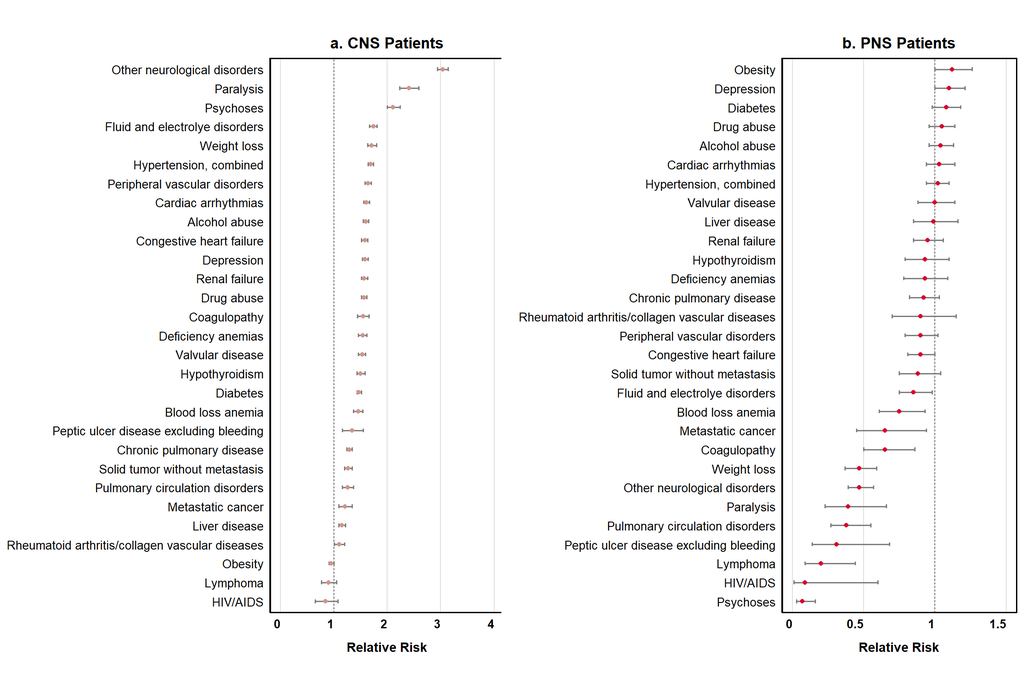

```r
# reformat data
rr_results_tidy_rr <- rr_results %>%
  select(Comorbidity, rr_CNS, rr_PNS) %>%
  pivot_longer(cols = rr_CNS:rr_PNS, names_to = "Neuro Status", values_to = "RR") %>%
  mutate(`Neuro Status` = if_else(`Neuro Status` == "rr_CNS", "CNS", "PNS"))

rr_results_tidy_l_ci <- rr_results %>%
  select(Comorbidity, l_ci_cns, l_ci_pns) %>%
  pivot_longer(cols = l_ci_cns:l_ci_pns, names_to = "Neuro Status", values_to = "l_CI") %>%
  mutate(`Neuro Status` = if_else(`Neuro Status` == "l_ci_cns", "CNS", "PNS"))

rr_results_tidy_u_ci <- rr_results %>%
  select(Comorbidity, u_ci_cns, u_ci_pns) %>%
  pivot_longer(cols = u_ci_cns:u_ci_pns, names_to = "Neuro Status", values_to = "u_CI") %>%
  mutate(`Neuro Status` = if_else(`Neuro Status` == "u_ci_cns", "CNS", "PNS"))

# combine all tidy results
rr_results_tidy <- rr_results_tidy_rr %>%
  left_join(., rr_results_tidy_l_ci,
                             by = c("Comorbidity", "Neuro Status")) %>%
  left_join(., rr_results_tidy_u_ci,
                             by = c("Comorbidity", "Neuro Status"))

# order by CNS diagnoses with higher RR
cns_top_results <- rr_results_tidy %>%
  filter(`Neuro Status` == "CNS") %>%
  arrange(RR) %>%
  select(Comorbidity)

rr_results_tidy$Comorbidity <-  ordered(rr_results_tidy$Comorbidity, levels = cns_top_results$Comorbidity)

cns_rr_plot <- ggplot(rr_results_tidy %>%
         filter(`Neuro Status` == "CNS"),
       aes(x = RR, y = Comorbidity)) +
  geom_vline(aes(xintercept = 1), size = .25, linetype = "dashed") +
    geom_errorbarh(aes(xmax = u_CI, xmin = l_CI), size = 0.7, height = 0.2, color = "gray50") +
    geom_point(size = 1.5, color = "#d1958a") +
    scale_x_continuous(breaks = seq(0, 4, 1), labels = seq(0, 4, 1),
                       limits = c(0,4)) +
  ylab("") +
  xlab("Relative Risk") +
  ggtitle("a. CNS Patients")

# arrange by top PNS results
pns_top_results <- rr_results_tidy %>%
  filter(`Neuro Status` == "PNS") %>%
  arrange(RR) %>%
  select(Comorbidity)

rr_results_tidy$Comorbidity <-  ordered(rr_results_tidy$Comorbidity, levels = pns_top_results$Comorbidity)


pns_rr_plot <- ggplot(rr_results_tidy %>%
         filter(`Neuro Status` == "PNS"),
       aes(x = RR, y = Comorbidity)) +
  geom_vline(aes(xintercept = 1), size = .25, linetype = "dashed") +
    geom_errorbarh(aes(xmax = u_CI, xmin = l_CI), size = 0.70, height = 0.2, color = "gray50") +
    geom_point(size = 1.5, color = "#d90429") +
    scale_x_continuous(breaks = seq(0, 1.5, 0.5), labels = seq(0, 1.5, 0.5),
                       limits = c(0,1.5)) +
  ylab("") +
  xlab("Relative Risk") +
  ggtitle("b. PNS Patients")

pns_rr_plot <- set_panel_size(pns_rr_plot,
                          width  = unit(7, "cm"),
                          height = unit(6.5, "in"))

cns_rr_plot <- set_panel_size(cns_rr_plot,
                          width  = unit(7, "cm"),
                          height = unit(6.5, "in"))

grid.arrange(cns_rr_plot, pns_rr_plot, ncol=2)
```

```r
ggsave("figures/Figure4.relative_risk.pdf", grid.arrange(cns_rr_plot, pns_rr_plot, ncol=2), width = 12, height = 8, dpi = 300)
```

### LPCA deviance explained

How much deviance is explained with 10 principal components for 30 comorbidity types?

Across all healthcare systems, 10 principal components explained above 75% of the deviance.

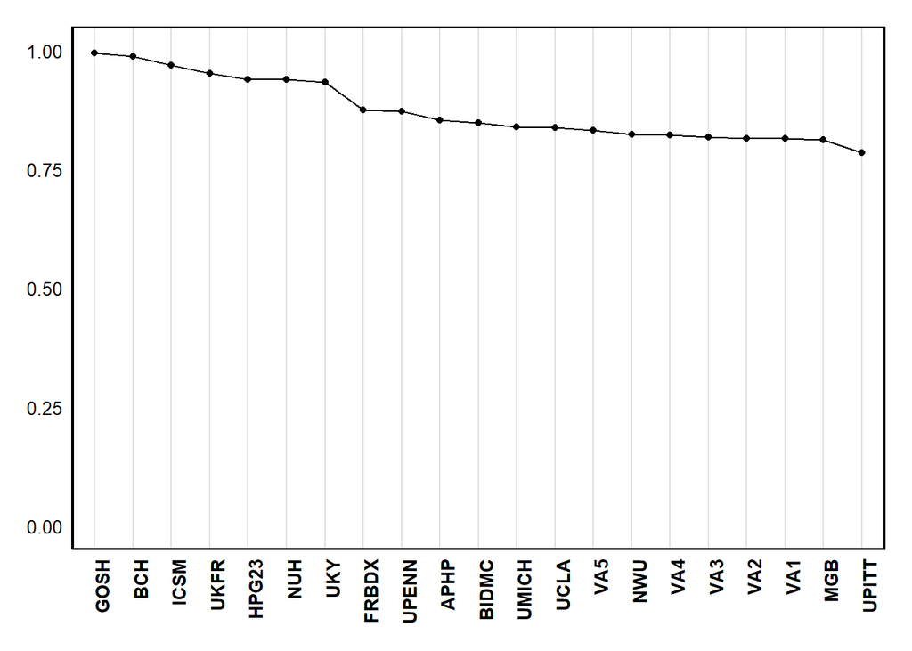

```r
pca_dev <- list()

for (i in sorted_sites) {
  tmp <- get(i)
  if (!is.null(tmp$deviance_expl)) {
    pca_dev[[i]] <- data.frame(site = tmp$site, dev_expl = tmp$deviance_expl)
  }
}

pca_plot <- bind_rows(pca_dev) %>%
  ggplot(aes(x = fct_reorder(site, -dev_expl), y = dev_expl, group = 1)) +
  geom_point() +
  geom_line() +
  coord_cartesian(ylim = c(0, 1)) +
  labs(y = "Proportion of Deviance explained", x = NULL) +
  theme(axis.text.x=element_text(angle=90, hjust=1)); pca_plot
```

```r
ggsave("figures/pca_deviance.png", pca_plot, height = 4, width = 6)
```